# Report cleaning tools

Flavia Leotta

18 February 2025

# Data

This report is about the efficiency of bioinformatic tools for GBS reads cleaning and trimming. The analyses were performed on de-multiplexed GBS reads of 10 populations of *Campanula thyrsoides* (subspecies Carniolica), on server asimina (IP: 159.149.160.43). Other files used comprehend a list of adapters in FASTA format (adapters_4.txt) and a txt file with the populations IDs (readpairs.txt).

# Fastq-mcf

Fastq-mcf is a standard tool that was used in a script (“02_clean.sh”) that creates a loop through through the populations and runs the following code:

```bash
fastq-mcf -q 30 -l 50 -k 0 -w 2 -o "output_path/read1_name" -o
"output_path/read2_name" adapters_4.txt "input_path/read1" "input_path/read2"
```

where parameters are:

- `-q 30 -l 50`: cuts low quality bases (Phred score < 30) and reads shorter than 50 bp;
- `-k 0:` disables skew filtering;
- `-w 2`: window-size for quality trimming;

For 10 populations (approximately 94M reads total) the total time is:

- real 30m5.595s
- user 39m56.789s
- sys 1m11.811s

# Fastp

Fastp is a similar tool that is able to take advantage of multithreading (max: 16 threads). The parameters are the following:

- `-i, -I` read1 and read2 inputs;
- `-o, -O` read1 and read2 outputs;
- `-q or --qualified_quality_phred` (quality value threshold);
- `-u or –unqualified_percent_limit` (percentage of allowed quality failing bases);
- `-3 or --cut_tail` (enables tail trimming);
- `--cut_tail_window_size --cut_tail_mean_quality` (per read cutting by phred);
- similarly, `-5 or --cut_front`, and `--cut_front_window_size` and `--cut_front_mean_quality`;
- `-l or --length_required` (min length);
- `-g or --trim_poly_g` (polyG tail trimming), `--poly_g_min_len` (min poly-G length);
- `--dont_eval_duplication` to disable the duplication evaluation (useless for GBS data);
- `--adapter_fasta`;
- `-w or --thread` (max 16).

The following tries were performed:

1. Try 1: only used tail trimming, with window size of 1. The mean quality doesn’t pass the tests.

**Show/hide code**

```bash
  fastp --in1 01_demulti/ALP1.1.fq.gz --in2 01_demulti/ALP1.2.fq.gz --out1
  02_clean_fastp/ALP1.1_clean.fq.gz --out2 02_clean_fastp/ALP1.2_clean.fq.gz
  --thread 16 --dont_eval_duplication --qualified_quality_phred 30
  --unqualified_percent_limit 40 --length_required 50 --cut_tail
  --cut_tail_window_size 1 --cut_tail_mean_quality 30 --trim_poly_g
  --poly_g_min_len 5 --adapter_fasta adapters_4.txt
```

2. Try 2: used cut_right instead of cut_tail. Passes the quality checks but it’s too stringent, and only 4% of the reads retained by fastq-mcf are retained (only 100K in comparison to 2.6M).

**Show/hide code**

```bash
  fastp --in1 01_demulti/ALP1.1.fq.gz --in2 01_demulti/ALP1.2.fq.gz
  --out1 02_clean_fastp/ALP1.1_clean.fq.gz
  --out2 02_clean_fastp/ALP1.2_clean.fq.gz --thread 16 --dont_eval_duplication
  --qualified_quality_phred 30 --unqualified_percent_limit 40 --length_required
  50 --cut_right --cut_right_window_size 1 --cut_right_mean_quality 30
  --trim_poly_g --poly_g_min_len 5 --adapter_fasta adapters_4.txt
```

3 and 4. Try 3 and 4: increased cut_tail_window_size up to 2 and 4 (fastp default). Didn’t really help with the quality as the problem is, on average, in the first couple of bases.

5. Try 5: added cut_front with window size of 1. The quality improves but it’s still failing.

**Show/hide code**

```bash
  fastp --in1 01_demulti/ALP1.1.fq.gz --in2 01_demulti/ALP1.2.fq.gz --out1
  02_clean_fastp/ALP1.1_clean.fq.gz --out2 02_clean_fastp/ALP1.2_clean.fq.gz
  --thread 20 --dont_eval_duplication --qualified_quality_phred 30
  --unqualified_percent_limit 40 --length_required 50 --cut_tail
  --cut_tail_window_size 1 --cut_tail_mean_quality 30 --trim_poly_g
  --poly_g_min_len 5 --cut_front --cut_front_window_size 1
  --cut_front_mean_quality 30 --adapter_fasta adapters_4.txt
```

6. Try 6: used the default cut_front_window_size of 4. This resulted in better quality than fastq-mcf but with a loss of 300k bases (a loss of 11.5% of reads).

7. Try 7: settled to cut_front_window_size of 2. This results in a loss of 200k bases (7.7%) but quality checks are passed.

8. Try 8: raised also cut_tail_window_size to 2, deletedcond the quality thresholds (-q 30 -u 40) and cut the tail after the trimming of the poly-G tail. This results in good quality and no loss of reads (tot: 2.6 M, for ALP1). The final code used for all the populations is found in the script 02_fastp.sh:

```bash
#!/bin/bash
# How to use: ./02_trim_fastp.sh path_to_reads/ readpairs.txt adapters.txt
mypath=$1;
adapters=$3;
readpairs=$2;
echo "$mypath";
#cd "$mypath";
for pair in $(cat "$readpairs")
do
    echo "";
    echo "Trimming $pair...";
    forward="$pair"".1.fq.gz";
    reverse="$pair"".2.fq.gz";
    # echo "$forward";
    # echo "$reverse";
    fwname="$(basename -s .fq.gz "$forward")""_clean_fastp.fq.gz";
    rvname="$(basename -s .fq.gz "$reverse")""_clean_fastp.fq.gz";
    # echo "$fwname";
    fastp --in1 "$mypath""$forward" --in2 "$mypath""$reverse" --out1
    "02_clean_fastp/""$fwname" --out2 "02_clean_fastp/""$rvname" --thread 16
    --dont_eval_duplication --length_required 50 --trim_poly_g --poly_g_min_len
    5 --cut_tail --cut_tail_window_size 2 --cut_tail_mean_quality 30 --cut_front
    --cut_front_window_size 2 --cut_front_mean_quality 30 --adapter_fasta
    adapters_4.txt;
    echo "Finished ""$pair"".";
done
```

And the total time running required to run over 10 populations (around 94M reads) using 16 threads is:

- real 4m24.012s
- user 62m2.110s
- sys 0m29.126s

A summary of other info about each try can be found here:

| TRY | AVG(L)R1 | AVG(L)R2 | TOT_READ1 | TOT_READ2 |
| --- | --- | --- | --- | --- |
| Fastq-mcf | 80 bp | 83 bp | 2.6 M | 2.6 M |
| Fastp-1 | 80 bp | 80 bp | 2.5 M | 2.5 M |
| Fastp-2 | 69 bp | 68 bp | 0.1 M | 0.1 M |
| Fastp-3 | 80 bp | 80 bp | 2.5 M | 2.5 M |
| Fastp-4 | 79 bp | 80 bp | 2.5 M | 2.5 M |
| Fastp-5 | 80 bp | 80 bp | 2.4 M | 2.4 M |
| Fastp-6 | 82 bp | 80 bp | 2.3 M | 2.3 M |
| Fastp-7 | 80 bp | 80 bp | 2.4 M | 2.4 M |
| Fastp-8 | 80 bp | 80 bp | 2.6 M | 2.6 M |

# Comparison between fastq-mcf and fastp

As the speed of fastp is evidently a big improvement, the amount of reads retained and the average quality might be harder to evaluate. Here’s some of the plots produced using fastqc (version 11.5) and multiqc (v 1.27.1).

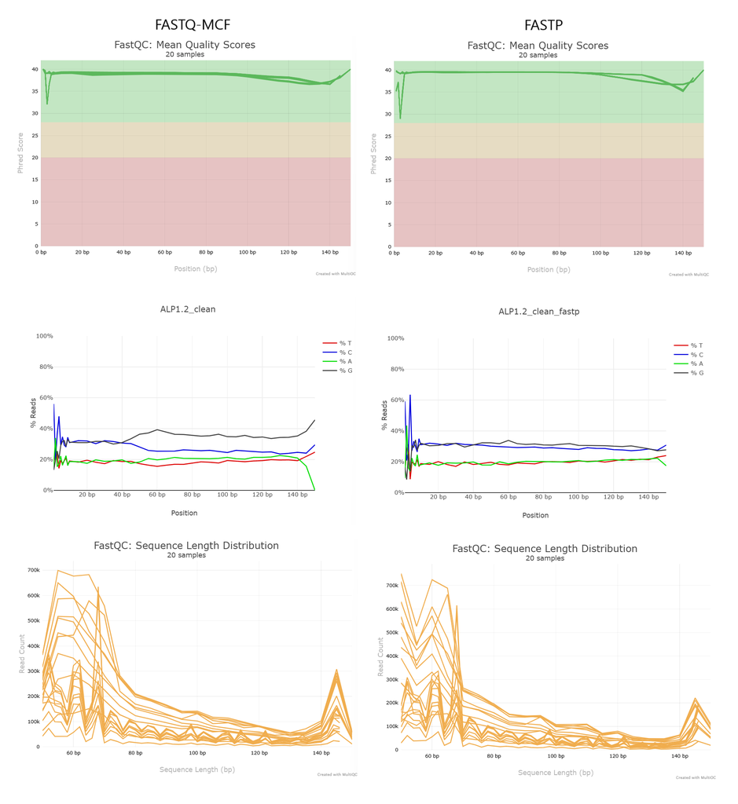

While the mean quality in fastp seems to be lower (first plots) when we look at the behavior along the reads length (second plot): fastp is able to guarantee more consistent quality, especially as the end of the reads is approached.

Similarly, in the third plot, we can see that, although the average length of reads appears similar, fastq-mcf seems to have more long reads (bp>140) in comparison to fastp. This might be due to how the poly-G tail is trimmed: fastp has an in-built tool for that, and might be better at cutting it, resulting in shorter reads.